# Práctica I - Software SAS Miner

Aplicando regresión multivariante y red neuronal a Beijing Multi-Site Air-Quality Data Set

Iván González Martín (Universidad Complutense de Madrid)https://ucm.es  
2023-04-09

# Contenido del dataset

El dataset que se presenta para su análisis en esta práctica reúne información acerca de distintos **contaminantes y características del aire** de **12 distritos y barrios** del área metropolitana de **Beijing**. Los datos climatológicos provienen del **Centro Municipal de Monitorización Ambiental de Beijing**, y se incluyen las mediciones **horarias** desde el **1 de marzo de 2013** hasta el **28 de febrero de 2017**. Para certificar la calidad de los datos, la información climatológica de cada distrito se compara previamente con la estación meteorológica más cercana perteneciente a la Administración Meteorológica de China.

Los **12 archivos CSV** que componen el dataset se han descargado del **UCI Machine Learning Repository** y no han sido modificados: [https://archive.ics.uci.edu/ml/datasets/Beijing+Multi-Site+Air-Quality+Data].

# Objetivo

El objetivo de esta práctica es **predecir** la variable **continua** `PM2.5` a través de las técnicas de **regresión multivariante** y de **red neuronal en modo regresión** con **selección de modelos**. **Para este segundo PDF, la práctica se resolverá con el software SAS Miner**.

La **materia particulada 2.5** (`PM2.5`) es un tipo de partícula muy pequeña, suspendida en el aire, que tiene un **diámetro de menos de 2.5 micras** y que se utiliza usualmente como medida de **contaminación atmosférica**. La monitorización de este tipo de partículas en grandes ciudades es **fundamental** debido a que son lo suficientemente pequeñas como para ser **inhaladas en los pulmones** y llegar al **torrente sanguíneo**. Ello puede provocar **consecuencias nocivas para la salud**, especialmente para personas con afecciones respiratorias como el **asma** o **enfermedades cardíacas**.

La exposición prolongada a niveles elevados de `PM2.5` también se ha relacionado con un **mayor riesgo** a padecer enfermedades cardiovasculares, respiratorias y cáncer de pulmón. Por esta razón, las regulaciones ambientales y de salud pública en la mayoría de países buscan **limitar la presencia de esta partícula en la atmósfera**.

Los modelos que en esta práctica se proponen están enfocados a **predecir la variable continua** `PM2.5` en función del resto de características **meteorológicas y de calidad del aire** de las que se disponen.

# Paquetes necesarios

Necesitaremos los siguientes paquetes:

```r
# Paquetes
library(tidymodels)
library(tidyverse)
library(parallel)
library(doParallel)
```

# Fase 1: Dataset inicial, selección de variables y división de particiones

Esta sección del trabajo se ha realizado **tras haber creado la receta** con todas las **modificaciones** sobre el dataset original en **R**, por lo que en SAS Miner, en lugar de emplear los datos originales, **se ha aprovechado ese dataset modificado para realizar la comparativa entre regresión y red neuronal**. Los **detalles más específicos** sobre los cambios que se han ido llevando a cabo en la receta (dummyficación, estandarización, etc.) se pueden consultar en el **primer PDF de la práctica** en donde se resuelve íntegramente con **lenguaje R**. En concreto, el dataset que se ha importado a SAS Miner tiene la siguiente forma:

```r
quality <- read_csv("/Users/leztin/Desktop/DATOS/quality.csv")
glimpse(quality)
```

```
Rows: 7,573
Columns: 23
$ SO2                   <dbl> 0.16914895, 0.07255860, 1.52141396, 5.…
$ CO                    <dbl> 0.97988237, -0.54824514, 0.88999252, 2…
$ O3                    <dbl> -0.8869409, -0.9948758, -0.9229192, -0…
$ Temp                  <dbl> -1.5258583, -0.6711939, -1.3252738, -0…
$ Wind_Speed            <dbl> -0.49390565, 0.64241066, -0.89973290, …
$ PM2_5                 <dbl> 257, 18, 60, 120, 63, 16, 3, 28, 253, …
$ Day_Weekend           <dbl> 0, 0, 0, 1, 1, 0, 0, 0, 0, 1, 1, 0, 0,…
$ Hour_Non.working.hour <dbl> 0, 1, 0, 0, 1, 1, 0, 1, 1, 1, 1, 0, 1,…
$ Rain_Yes              <dbl> 0, 0, 0, 0, 0, 0, 0, 0, 0, 0, 0, 0, 0,…
$ Wind_Dir_North        <dbl> 0, 0, 1, 0, 1, 0, 1, 0, 0, 1, 1, 1, 0,…
$ Wind_Dir_South        <dbl> 0, 0, 0, 0, 0, 0, 0, 0, 0, 0, 0, 0, 0,…
$ Wind_Dir_West         <dbl> 0, 0, 0, 0, 0, 0, 0, 0, 0, 0, 0, 0, 1,…
$ Station_Changping     <dbl> 0, 1, 1, 0, 0, 0, 0, 0, 0, 0, 1, 0, 0,…
$ Station_Dingling      <dbl> 0, 0, 0, 0, 0, 1, 0, 0, 0, 0, 0, 0, 0,…
$ Station_Dongsi        <dbl> 0, 0, 0, 0, 0, 0, 1, 0, 0, 0, 0, 0, 0,…
$ Station_Guanyuan      <dbl> 0, 0, 0, 0, 0, 0, 0, 0, 0, 1, 0, 0, 0,…
$ Station_Gucheng       <dbl> 0, 0, 0, 0, 1, 0, 0, 0, 0, 0, 0, 1, 0,…
$ Station_Huairou       <dbl> 0, 0, 0, 0, 0, 0, 0, 0, 0, 0, 0, 0, 1,…
$ Station_Nongzhanguan  <dbl> 0, 0, 0, 1, 0, 0, 0, 1, 0, 0, 0, 0, 0,…
$ Station_Shunyi        <dbl> 0, 0, 0, 0, 0, 0, 0, 0, 0, 0, 0, 0, 0,…
$ Station_Tiantan       <dbl> 1, 0, 0, 0, 0, 0, 0, 0, 1, 0, 0, 0, 0,…
$ Station_Wanliu        <dbl> 0, 0, 0, 0, 0, 0, 0, 0, 0, 0, 0, 0, 0,…
$ Station_Wanshouxigong <dbl> 0, 0, 0, 0, 0, 0, 0, 0, 0, 0, 0, 0, 0,…
```

Como se puede observar, las variables **cualitativas** ya están **dummyficadas** y las **cuantitativas normalizadas**.

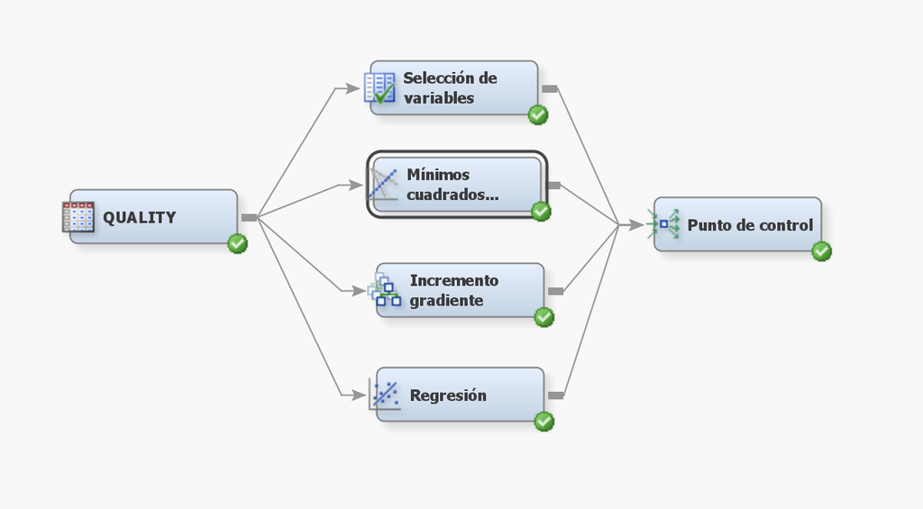

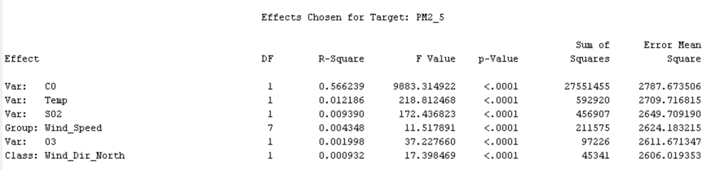

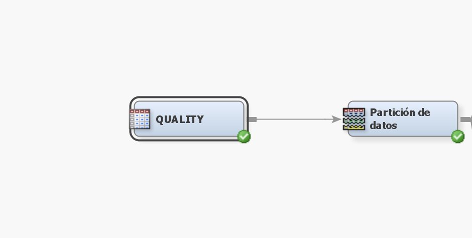

# Fase 2: Ejecución y tuneo de los algoritmos

Una vez definidas las distintas particiones con las diferentes semillas, introducimos los nodos de **«regresión»** y de **«red neuronal»**.

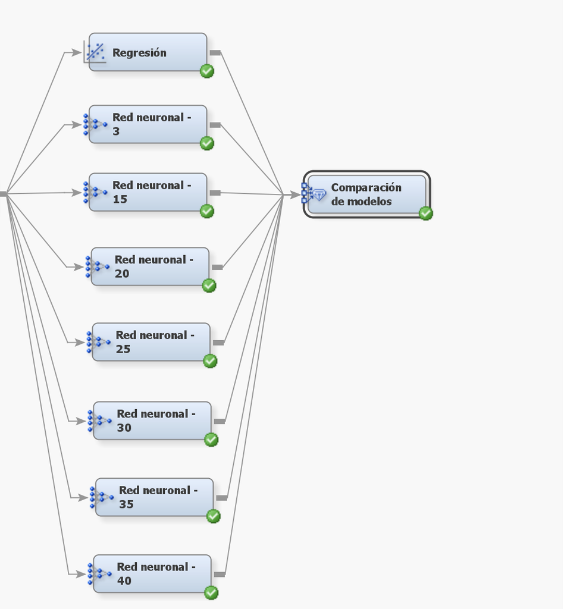

Por otra parte, las **iteraciones** se han modificado a **1000** en todos los nodos **como máximo**, y los **algoritmos** y **funciones de activación** se han mantenido en **predeterminado**. Tras varias pruebas con diferentes algoritmos (Levenberg-Marquardt, Quasi-Newton, BackProp, RPROP, etc.), la opción predeterminada era la que **ofrecía mejores resultados** (47-48 de $RMSE$).

# Fase 3: Comparación de los resultados

Tras ejecutar todos los nodos que hemos definido, en esta sección **analizaremos los resultados que nos arrojan**. Mostraremos el $TRASE$ de los resultados de algunas semillas de aleatorización a modo de ejemplo.

**Vista completa de la semilla 123457**

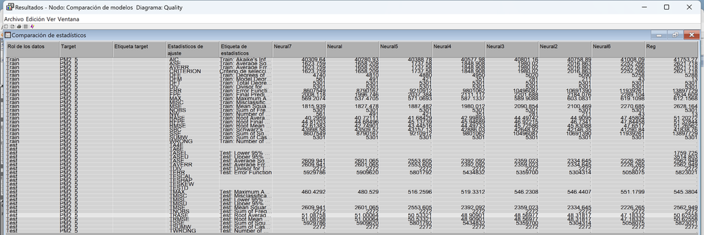

**Semilla 12347:**

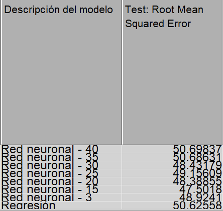

**Semilla 12348:**

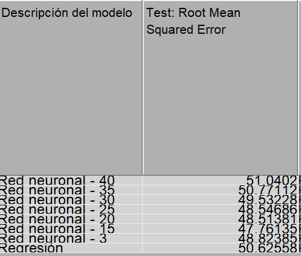

**Semilla 12349:**

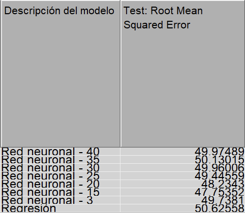

**Semilla 12350:**

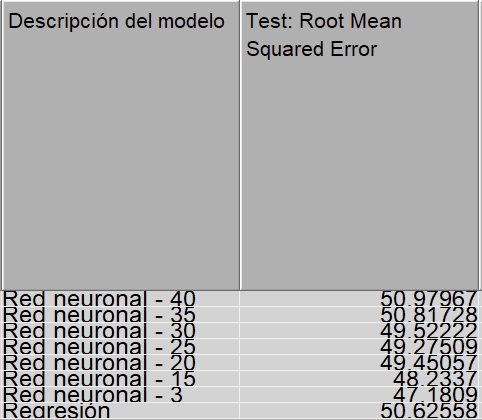

**Semilla 12351:**

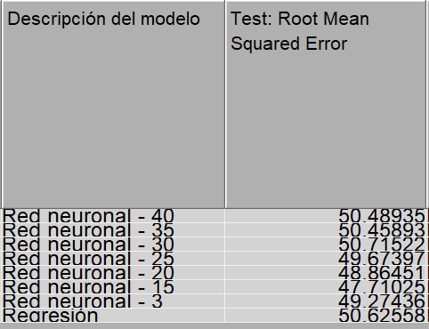

Como se puede observar en la tabla de la «visión completa», **los resultados de las redes neuronales en train mejoran el** $RMSE$ **de la regresión en 8 puntos**. Además, a medida que **aumentan los nodos**, el **error** de las redes neuronales **disminuye** (a costa de incrementar también su complejidad): la red neuronal de 15 nodos ofrece un RMSE de 45.83, mientras que la de 40 nodos es de 42.61.

Ante estos resultados, y a modo de conclusión, yo me quedaría, o con la **red neuronal de 15 nodos** (menos complejidad, y mayor precisión en datos test); o con la **regresión**. Los **modelos clásicos** como la regresión son **menos complejos** que cualquier red neuronal, emplean menos parámetros, y, en este caso, **las diferencias en el error no son tan significativas**. En datos test, la regresión se posiciona con un error del 50.62, mientras que la mejor red neuronal consigue rebajar a 47.5. **Son tan solo tres puntos de diferencia en el error** a costa de reducir la complejidad del modelo en gran medida (de 211 a 13 parámetros que presenta la regresión). Dependiendo de las características específicas del modelo que se prefiera construir, podríamos decantarnos por cualquiera de los dos.

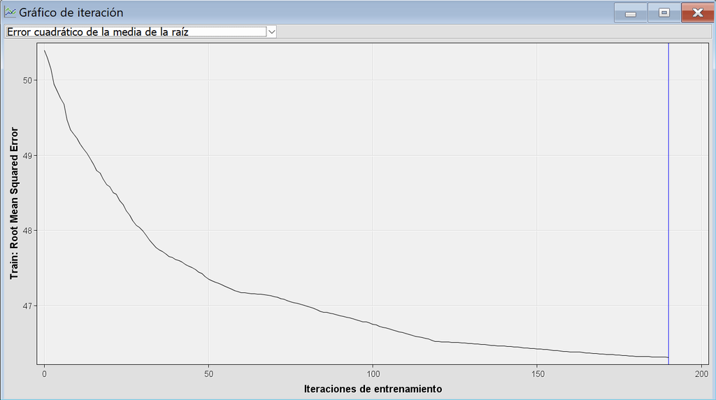

En cuanto a las **iteraciones**, recordemos que dispusimos **1000 como máximo para cada red neuronal**. Como se puede observar en el gráfico, el $RMSE$ de todas las redes suele **estabilizarse en torno a las 200 iteraciones**. Por encima de este nivel, el error permanece **constante** o, incluso, **empeora**.

# Fase 4: Tabla comparativa básica de todos los modelos construidos

```r
knitr::kable(Modelos, row.names = FALSE, align = "c")
```

| Modelo | Variables | Size | Decay | Iter | RMSE | Rsquared | MAE | RMSESD | RsquaredSD | MAESD |
| --- | --- | --- | --- | --- | --- | --- | --- | --- | --- | --- |
| Reg. lineal Filtro SBF | 16 | NA | NA | NA | 48.12680 | 0.6211469 | 31.62938 | 1.824305 | 0.0230218 | 0.5884595 |
| Reg. lineal Wrapper RFE | 8 | NA | NA | NA | 48.28023 | 0.6187292 | 31.74797 | 1.809805 | 0.0229429 | 0.5863130 |
| Reg. lineal Algoritmo SES | 6 | NA | NA | NA | 49.29362 | 0.6024187 | 33.17810 | 1.700602 | 0.0216726 | 0.5869939 |
| Reg. lineal Algoritmo MMPC | 6 | NA | NA | NA | 48.37444 | 0.6171964 | 31.83755 | 1.806547 | 0.0229044 | 0.6096542 |
| Reg. lineal Algoritmo Boruta | 12 | NA | NA | NA | 48.15084 | 0.6207601 | 31.64198 | 1.815730 | 0.0229553 | 0.5825930 |
| Reg. lineal Criterio AIC | 14 | NA | NA | NA | 48.14271 | 0.6208840 | 31.65135 | 1.815765 | 0.0229674 | 0.5809674 |
| Reg. lineal Criterio BIC | 9 | NA | NA | NA | 48.22090 | 0.6196589 | 31.68954 | 1.817478 | 0.0231472 | 0.5864442 |
| Reg. lineal Step Repetido AIC (set 1) | 12 | NA | NA | NA | 48.18784 | 0.6201897 | 31.64887 | 1.822174 | 0.0231778 | 0.5800286 |
| Reg. lineal Step Repetido BIC (set 1) | 6 | NA | NA | NA | 48.29492 | 0.6184985 | 31.69963 | 1.826474 | 0.0233018 | 0.5875319 |
| Reg. lineal Step Repetido AIC (set 2) | 12 | NA | NA | NA | 48.17972 | 0.6203181 | 31.67154 | 1.823605 | 0.0230883 | 0.5815480 |
| Reg. lineal Step Repetido BIC (set 2) | 9 | NA | NA | NA | 48.24420 | 0.6192797 | 31.70714 | 1.812094 | 0.0230232 | 0.5876640 |
| Reg. lineal Set de SAS Miner | 5 | NA | NA | NA | 50.62550 | 0.6012239 | NA | NA | NA | NA |
| Red neuronal (sin tunear) Criterio BIC | 9 | 15 | 0.010 | 100 | 45.96425 | 0.6541997 | 29.21047 | 1.744605 | 0.0202657 | 0.5698941 |
| Red neuronal (sin tunear) Step Repetido Criterio BIC (set 1) | 6 | 15 | 0.001 | 100 | 45.95087 | 0.6544157 | 29.10019 | 1.757652 | 0.0202516 | 0.5993611 |
| Red neuronal tuneada Criterio BIC | 9 | 20 | 0.010 | 300 | 45.59003 | 0.6598896 | 29.01463 | 1.797445 | 0.0209876 | 0.6227855 |
| Red neuronal tuneada Step Repetido Criterio BIC (set 1) | 6 | 25 | 0.100 | 1000 | 45.40948 | 0.6625800 | 28.83020 | 1.758132 | 0.0204519 | 0.5957253 |
| Red neuronal Set de SAS Miner | 5 | 15 | 0.100 | 300 | 47.75352 | 0.6347654 | NA | NA | NA | NA |

A modo de conclusión, en la tabla anterior se muestran para su consulta **los resultados de todos los modelos** que se han ido generando **tanto en R como en SAS Miner** sobre este dataset. Como ya se comentó, el mejor modelo parece ser el de la **«Red neuronal tuneada - step repetido Criterio BIC (set 1)»**, con 6 variables, un $RMSE$ de $45.40948$ y un $R^2$ de $66.26$ %.

Como sección extra, efectuaremos a continuación una **comparación básica** de la **performance** entre los resultados generados a través de **SAS Miner** y los generados previamente a través de **R** a partir de un **esquema simple training-test**.

# Extra: Comparación de la performance entre SAS y R

Para la **comparación de la performance** entre los resultados obtenidos desde **ambos softwares**, lo que haremos será seguir el procedimiento detallado en el archivo `comparar SAS y R.R`.

## Creación de las particiones train y test

Para no tener que realizar de nuevo todo el procesado del dataset original, **se empleará el dataset tratado del primer PDF de la práctica**. Este dataset adquiere la siguiente forma:

```r
glimpse(quality)
```

```
Rows: 7,573
Columns: 23
$ SO2                   <dbl> 0.16914895, 0.07255860, 1.52141396, 5.…
$ CO                    <dbl> 0.97988237, -0.54824514, 0.88999252, 2…
$ O3                    <dbl> -0.8869409, -0.9948758, -0.9229192, -0…
$ Temp                  <dbl> -1.5258583, -0.6711939, -1.3252738, -0…
$ Wind_Speed            <dbl> -0.49390565, 0.64241066, -0.89973290, …
$ PM2_5                 <dbl> 257, 18, 60, 120, 63, 16, 3, 28, 253, …
$ Day_Weekend           <dbl> 0, 0, 0, 1, 1, 0, 0, 0, 0, 1, 1, 0, 0,…
$ Hour_Non.working.hour <dbl> 0, 1, 0, 0, 1, 1, 0, 1, 1, 1, 1, 0, 1,…
$ Rain_Yes              <dbl> 0, 0, 0, 0, 0, 0, 0, 0, 0, 0, 0, 0, 0,…
$ Wind_Dir_North        <dbl> 0, 0, 1, 0, 1, 0, 1, 0, 0, 1, 1, 1, 0,…
$ Wind_Dir_South        <dbl> 0, 0, 0, 0, 0, 0, 0, 0, 0, 0, 0, 0, 0,…
$ Wind_Dir_West         <dbl> 0, 0, 0, 0, 0, 0, 0, 0, 0, 0, 0, 0, 1,…
$ Station_Changping     <dbl> 0, 1, 1, 0, 0, 0, 0, 0, 0, 0, 1, 0, 0,…
$ Station_Dingling      <dbl> 0, 0, 0, 0, 0, 1, 0, 0, 0, 0, 0, 0, 0,…
$ Station_Dongsi        <dbl> 0, 0, 0, 0, 0, 0, 1, 0, 0, 0, 0, 0, 0,…
$ Station_Guanyuan      <dbl> 0, 0, 0, 0, 0, 0, 0, 0, 0, 1, 0, 0, 0,…
$ Station_Gucheng       <dbl> 0, 0, 0, 0, 1, 0, 0, 0, 0, 0, 0, 1, 0,…
$ Station_Huairou       <dbl> 0, 0, 0, 0, 0, 0, 0, 0, 0, 0, 0, 0, 1,…
$ Station_Nongzhanguan  <dbl> 0, 0, 0, 1, 0, 0, 0, 1, 0, 0, 0, 0, 0,…
$ Station_Shunyi        <dbl> 0, 0, 0, 0, 0, 0, 0, 0, 0, 0, 0, 0, 0,…
$ Station_Tiantan       <dbl> 1, 0, 0, 0, 0, 0, 0, 0, 1, 0, 0, 0, 0,…
$ Station_Wanliu        <dbl> 0, 0, 0, 0, 0, 0, 0, 0, 0, 0, 0, 0, 0,…
$ Station_Wanshouxigong <dbl> 0, 0, 0, 0, 0, 0, 0, 0, 0, 0, 0, 0, 0,…
```

Realizaremos a continuación las **particiones** sobre este dataset. Destinaremos el **70 % a train** y el **30 % a test**. Como el dataset cuenta con **7573 observaciones**, el grupo de **entrenamiento** estará compuesto por **5302 observaciones**, mientras que el conjunto **test** contará con **2271 observaciones**.

```r
# Fijamos semilla
set.seed(12345)

# Calculamos el tamaño muestral del grupo test
sample_size <-
  floor(0.3 * nrow(quality))

# Generamos los índices para la partición
indices <-
  sample(seq_len(nrow(quality)), size = sample_size)

# Creamos las particiones
test <-
  quality[indices,]
train <-
  quality[-indices,]

# Las pasamos a dataframe. Las funciones posteriores no admiten tibble.
test <- test |>
  as.data.frame()
train <- train |>
  as.data.frame()
```

Una vez realizadas las particiones, **generamos los archivos** para poder subirlos a **SAS Miner**.

```r
write_csv(train, "train.csv")
write_csv(test, "test.csv")
```

## Comparación de la performance entre SAS Miner y R

Con las **particiones cargadas** en R y en SAS Miner, recopilaremos los hiperparámetros del mejores modelo obtenido en R. Lo **entrenaremos** con la **partición train** y realizaremos las **predicciones** sobre la **partición test**.

### Resultados del modelo en R

Tal y como se indica en el **primer PDF**, el modelo finalmente seleccionado fue la **red neuronal con las variables proporcionadas por el método del step repetido basado en el Criterio BIC** (6 variables) y con la siguiente configuración de hiperparámetros: `size = 25`, `decay = 0.1`, e `iter = 1000`. A continuación aplicaremos este modelo a los datos de entrenamiento para, posteriormente, calcular las **predicciones sobre datos test**.

```r
library(caret)

#Fijamos semilla
set.seed(12346)

# Inicializamos la paralelización
clusters <- detectCores() - 1
make_cluster <- makeCluster(clusters)
registerDoParallel(make_cluster)

# Generamos el grid y los parámetros de control
nnetgrid <-
  expand.grid(size=c(25), decay=c(0.1), bag=F)

control <-
  trainControl(method = "repeatedcv", number = 4,
               repeats = 5, savePredictions = "all")

# Lanzamos el modelo
rednnet <-
  train(PM2_5~CO + Temp + SO2 + Hour_Non.working.hour + Rain_Yes + Wind_Dir_South,
        data = train, method = "avNNet",
        linout = TRUE, trControl = control,
        repeats = 5, tuneGrid = nnetgrid,
        maxit = 1000, trace = FALSE)

# Calculamos las predicciones sobre datos test
predicciones <-
  predict(rednnet, test)

# Añadimos las predicciones al grupo test y calculamos el error
completo <-
  cbind(test, predicciones)

completo$error <-
  (completo$PM2_5-completo$predicciones)^2

MSE <- mean(completo$error)
RMSE <- sqrt(MSE)

# Finalizamos la paralelización
stopCluster(make_cluster)
registerDoSEQ()
```

A la vista de los resultados, este modelo en **R** presenta un $MSE$ de **2352.3** y un $RMSE$ de **48.5** sobre datos test. Comprobemos ahora estos valores en SAS Miner.

### Resultados del modelo en SAS Miner

Para reproducir el modelo en **SAS Miner**, lo primero que haremos será **cargar los archivos train y test** como **fuentes de datos**. Tras ello, descartaremos las variables que no están incluidas en nuestro modelo original: nos quedamos únicamente con **6 variables más la objetivo**.

[figure not shown]

Una vez preparadas nuestras dos fuentes de datos, acoplamos los **nodos de «red neuronal» y «puntuación»** a la **fuente de datos «train»**. A la **fuente de datos «test»** la unimos con el **rol de puntuación** al nodo del mismo nombre para obtener las puntuaciones sobre esa fuente de datos.

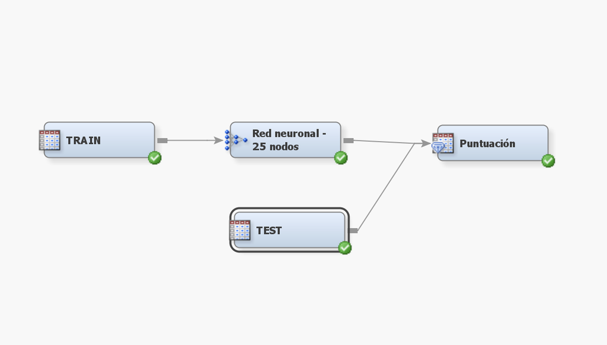

En cuanto a los **parámetros del nodo de la red neuronal**, se dispusieron igual que en la construcción del modelo en R. Concretamente **25 nodos**, **1000 iteraciones**, y un **decay o learning rate** de **0.1**. Para cambiar el learning rate, se optó por modificar el algoritmo predeterminado a **Back Prop**, que es uno de los pocos que **permiten alterar este parámetro**.

[figure not shown]

Una vez ejecutado todo, **se extrajeron las puntuaciones** a través del nodo **«exportar código de puntuación»**, se exportaron a formato sas7bdat, y **se volvieron a importar como nueva fuente de datos** (SCOREDATA).

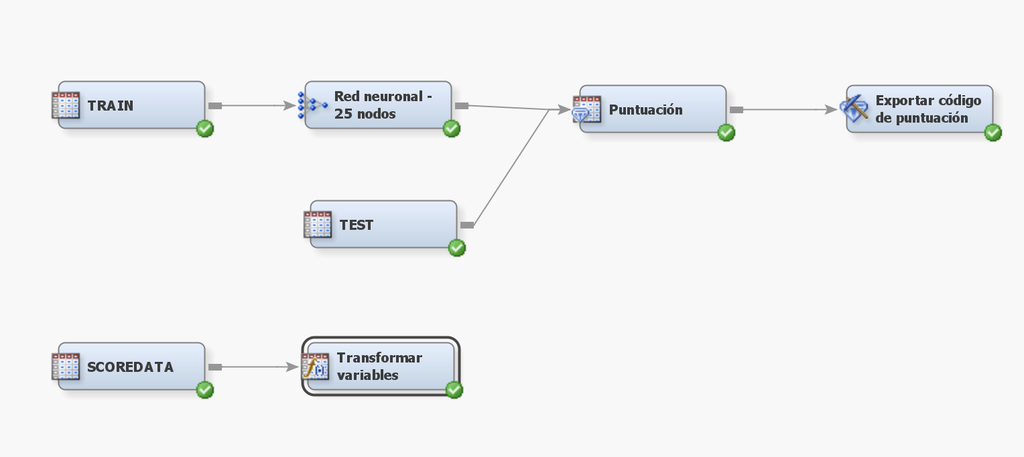

Con las **predicciones** ya incluidas como una nueva variable dentro del dataset, se conectó con el nodo **«transformar variables»** y se calculó la siguiente fórmula para obtener el $MSE$: $(P\_PM2.5-PM2.5)^2$.

[figure not shown]

Finalmente, el valor del $MSE$ en SAS Miner fue de **2177.783**. Por su parte, el $RMSE$ es igual a **46.67**, valor **inferior en dos puntos al obtenido a través del método en R (48.5)**. En esta ocasión, los resultados a través de las técnicas que emplea el software SAS Miner son **ligeramente superiores**.

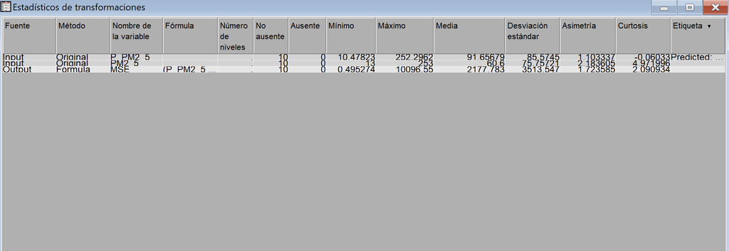

**¡Muchas gracias por la atención!**